# Capstone Quiz I

```r
library(dplyr)
```

```r
library(ggplot2)
library(statsr)
```

Complete all **Exercises**, and submit answers to **Questions** on the Coursera platform.

This initial quiz will concern exploratory data analysis (EDA) of the Ames Housing dataset. EDA is essential when working with any source of data and helps inform modeling.

First, let us load the data:

```r
load("ames_train.Rdata")
```

1. Which of the following are the three variables with the highest number of missing observations?
   1. `Misc.Feature`, `Fence`, `Pool.QC`
   2. **`Misc.Feature`, `Alley`, `Pool.QC`**
   3. `Pool.QC`, `Alley`, `Fence`
   4. `Fireplace.Qu`, `Pool.QC`, `Lot.Frontage`

```r
# type your code for Question 1 here, and Knit
sapply(ames_train, function(x) sum(is.na(x)))
```

```
##             PID            area           price     MS.SubClass       MS.Zoning
##               0               0               0               0               0
##    Lot.Frontage        Lot.Area          Street           Alley       Lot.Shape
##             167               0               0             933               0
##    Land.Contour       Utilities      Lot.Config      Land.Slope    Neighborhood
##               0               0               0               0               0
##     Condition.1     Condition.2       Bldg.Type     House.Style    Overall.Qual
##               0               0               0               0               0
##    Overall.Cond      Year.Built  Year.Remod.Add      Roof.Style       Roof.Matl
##               0               0               0               0               0
##    Exterior.1st    Exterior.2nd    Mas.Vnr.Type    Mas.Vnr.Area      Exter.Qual
##               0               0               0               7               0
##      Exter.Cond      Foundation       Bsmt.Qual       Bsmt.Cond   Bsmt.Exposure
##               0               0              21              21              21
##  BsmtFin.Type.1    BsmtFin.SF.1  BsmtFin.Type.2    BsmtFin.SF.2     Bsmt.Unf.SF
##              21               1              21               1               1
##   Total.Bsmt.SF         Heating      Heating.QC     Central.Air      Electrical
##               1               0               0               0               0
##     X1st.Flr.SF     X2nd.Flr.SF Low.Qual.Fin.SF  Bsmt.Full.Bath  Bsmt.Half.Bath
##               0               0               0               1               1
##       Full.Bath       Half.Bath   Bedroom.AbvGr   Kitchen.AbvGr    Kitchen.Qual
##               0               0               0               0               0
##   TotRms.AbvGrd      Functional      Fireplaces    Fireplace.Qu     Garage.Type
##               0               0               0             491              46
##   Garage.Yr.Blt   Garage.Finish     Garage.Cars     Garage.Area     Garage.Qual
##              48              46               1               1              47
##     Garage.Cond     Paved.Drive    Wood.Deck.SF   Open.Porch.SF  Enclosed.Porch
##              47               0               0               0               0
##     X3Ssn.Porch    Screen.Porch       Pool.Area         Pool.QC           Fence
##               0               0               0             997             798
##    Misc.Feature        Misc.Val         Mo.Sold         Yr.Sold       Sale.Type
##             971               0               0               0               0
##  Sale.Condition
##               0
```

2. How many categorical variables are coded in R as having type `int`? Change them to factors when conducting your analysis.
   1. 0
   2. 1
   3. 2
   4. **3**

```r
# type your code for Question 2 here, and Knit
summary(ames_train)
```

```
##       PID                 area          price         MS.SubClass
##  Min.   :5.263e+08   Min.   : 334   Min.   : 12789   Min.   : 20.00
##  1st Qu.:5.285e+08   1st Qu.:1092   1st Qu.:129763   1st Qu.: 20.00
##  Median :5.354e+08   Median :1411   Median :159467   Median : 50.00
##  Mean   :7.059e+08   Mean   :1477   Mean   :181190   Mean   : 57.15
##  3rd Qu.:9.071e+08   3rd Qu.:1743   3rd Qu.:213000   3rd Qu.: 70.00
##  Max.   :1.007e+09   Max.   :4676   Max.   :615000   Max.   :190.00
##
##    MS.Zoning    Lot.Frontage       Lot.Area       Street     Alley
##  A (agr):  0   Min.   : 21.00   Min.   :  1470   Grvl:  3   Grvl: 33
##  C (all):  9   1st Qu.: 57.00   1st Qu.:  7314   Pave:997   Pave: 34
##  FV     : 56   Median : 69.00   Median :  9317              NA's:933
##  I (all):  1   Mean   : 69.21   Mean   : 10352
##  RH     :  7   3rd Qu.: 80.00   3rd Qu.: 11650
##  RL     :772   Max.   :313.00   Max.   :215245
##  RM     :155   NA's   :167
##  Lot.Shape Land.Contour  Utilities      Lot.Config  Land.Slope  Neighborhood
##  IR1:338   Bnk: 33      AllPub:1000   Corner :173   Gtl:962    NAmes  :155
##  IR2: 30   HLS: 38      NoSeWa:   0   CulDSac: 76   Mod: 33    CollgCr: 85
##  IR3:  3   Low: 20      NoSewr:   0   FR2    : 36   Sev:  5    Somerst: 74
##  Reg:629   Lvl:909                    FR3    :  5              OldTown: 71
##                                       Inside :710              Sawyer : 61
##                                                                Edwards: 60
##                                                                (Other):494
##   Condition.1   Condition.2   Bldg.Type    House.Style   Overall.Qual
##  Norm   :875   Norm   :988   1Fam  :823   1Story :521   Min.   : 1.000
##  Feedr  : 53   Feedr  :  6   2fmCon: 20   2Story :286   1st Qu.: 5.000
##  Artery : 23   Artery :  2   Duplex: 35   1.5Fin : 98   Median : 6.000
##  RRAn   : 14   PosN   :  2   Twnhs : 38   SLvl   : 41   Mean   : 6.095
##  PosN   : 11   PosA   :  1   TwnhsE: 84   SFoyer : 36   3rd Qu.: 7.000
##  RRAe   : 11   RRNn   :  1                2.5Unf : 10   Max.   :10.000
##  (Other): 13   (Other):  0                (Other):  8
##   Overall.Cond     Year.Built   Year.Remod.Add   Roof.Style    Roof.Matl
##  Min.   :1.000   Min.   :1872   Min.   :1950   Flat   :  9   CompShg:984
##  1st Qu.:5.000   1st Qu.:1955   1st Qu.:1966   Gable  :775   Tar&Grv: 11
##  Median :5.000   Median :1975   Median :1992   Gambrel:  8   WdShake:  2
##  Mean   :5.559   Mean   :1972   Mean   :1984   Hip    :204   WdShngl:  2
##  3rd Qu.:6.000   3rd Qu.:2001   3rd Qu.:2004   Mansard:  4   Metal  :  1
##  Max.   :9.000   Max.   :2010   Max.   :2010   Shed   :  0   ClyTile:  0
##                                                              (Other):  0
```

[output cut: 81 more lines]

```
##  Min.   :  0.000   Ex  :  1   GdPrv: 43   Elev:  0     Min.   :    0.00
##  1st Qu.:  0.000   Fa  :  1   GdWo : 37   Gar2:  2     1st Qu.:    0.00
##  Median :  0.000   Gd  :  1   MnPrv:120   Othr:  1     Median :    0.00
##  Mean   :  1.463   TA  :  0   MnWw :  2   Shed: 25     Mean   :   45.81
##  3rd Qu.:  0.000   NA's:997   NA's :798   TenC:  1     3rd Qu.:    0.00
##  Max.   :800.000                          NA's:971     Max.   :15500.00
##
##     Mo.Sold          Yr.Sold       Sale.Type   Sale.Condition
##  Min.   : 1.000   Min.   :2006   WD     :863   Abnorml: 61
##  1st Qu.: 4.000   1st Qu.:2007   New    : 79   AdjLand:  2
##  Median : 6.000   Median :2008   COD    : 27   Alloca :  4
##  Mean   : 6.243   Mean   :2008   ConLD  :  7   Family : 17
##  3rd Qu.: 8.000   3rd Qu.:2009   ConLw  :  6   Normal :834
##  Max.   :12.000   Max.   :2010   Con    :  5   Partial: 82
##                                  (Other): 13
```

```r
str(ames_train)
```

```
## tibble [1,000 x 81] (S3: tbl_df/tbl/data.frame)
##  $ PID            : int [1:1000] 909176150 905476230 911128020 535377150 534177230 908128060 902135020 528228540 923426010 908186050 ...
##  $ area           : int [1:1000] 856 1049 1001 1039 1665 1922 936 1246 889 1072 ...
##  $ price          : int [1:1000] 126000 139500 124900 114000 227000 198500 93000 187687 137500 140000 ...
##  $ MS.SubClass    : int [1:1000] 30 120 30 70 60 85 20 20 20 180 ...
##  $ MS.Zoning      : Factor w/ 7 levels "A (agr)","C (all)",..: 6 6 2 6 6 6 7 6 6 7 ...
##  $ Lot.Frontage   : int [1:1000] NA 42 60 80 70 64 60 53 74 35 ...
##  $ Lot.Area       : int [1:1000] 7890 4235 6060 8146 8400 7301 6000 3710 12395 3675 ...
##  $ Street         : Factor w/ 2 levels "Grvl","Pave": 2 2 2 2 2 2 2 2 2 2 ...
##  $ Alley          : Factor w/ 2 levels "Grvl","Pave": NA NA NA NA NA NA 2 NA NA NA ...
##  $ Lot.Shape      : Factor w/ 4 levels "IR1","IR2","IR3",..: 4 4 4 4 4 4 4 4 4 4 ...
##  $ Land.Contour   : Factor w/ 4 levels "Bnk","HLS","Low",..: 4 4 4 4 4 4 1 4 4 4 ...
##  $ Utilities      : Factor w/ 3 levels "AllPub","NoSeWa",..: 1 1 1 1 1 1 1 1 1 1 ...
##  $ Lot.Config     : Factor w/ 5 levels "Corner","CulDSac",..: 1 5 5 1 5 1 5 5 1 5 ...
##  $ Land.Slope     : Factor w/ 3 levels "Gtl","Mod","Sev": 1 1 1 1 1 1 2 1 1 1 ...
```

[output cut: 67 more lines]

3. In terms of price, which neighborhood has the highest standard deviation?
   1. **`StoneBr`**
   2. `Timber`
   3. `Veenker`
   4. `NridgHt`

```r
d1 = setNames(aggregate(ames_train$price, list(ames_train$Neighborhood), sd), c('Neighborhood', 'SdPrice'))
d1[order(d1$SdPrice, decreasing = TRUE), ]
```

```
##    Neighborhood   SdPrice
## 24      StoneBr 123459.10
## 18      NridgHt 105088.90
## 26       Timber  84029.57
## 27      Veenker  72545.41
## 7       Crawfor  71267.56
## 11      GrnHill  70710.68
## 23      Somerst  65199.49
## 8       Edwards  54851.63
## 6       CollgCr  52786.08
## 22      SawyerW  48354.36
## 5       ClearCr  48068.69
## 19       NWAmes  41340.50
## 9       Gilbert  41190.38
## 14      Mitchel  39682.94
## 4       BrkSide  37309.91
## 20      OldTown  36429.69
## 16      NoRidge  35888.97
## 12       IDOTRR  31530.44
## 10       Greens  29063.42
## 25        SWISU  27375.76
## 15        NAmes  27267.97
## 1       Blmngtn  26454.86
## 21       Sawyer  21216.22
## 13      MeadowV  18939.78
## 3        BrDale  13337.59
## 17      NPkVill  11958.37
## 2       Blueste  10381.23
```

4. Using scatter plots or other graphical displays, which of the following variables appears to be the best single predictor of `price`?
   1. `Lot.Area`
   2. `Bedroom.AbvGr`
   3. **`Overall.Qual`**
   4. `Year.Built`

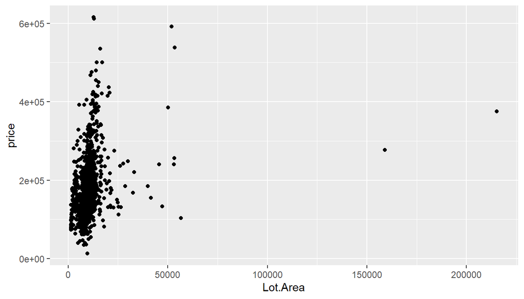

```r
# type your code for Question 4 here, and Knit
ggplot(ames_train, aes(x = Lot.Area, y = price)) +
  geom_point()
```

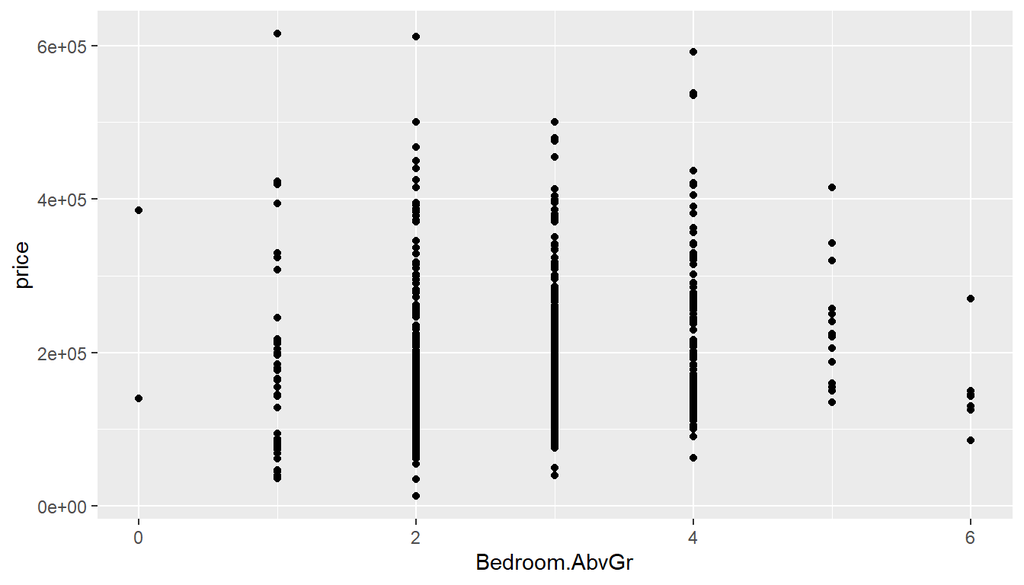

```r
ggplot(ames_train, aes(x = Bedroom.AbvGr, y = price)) +
  geom_point()
```

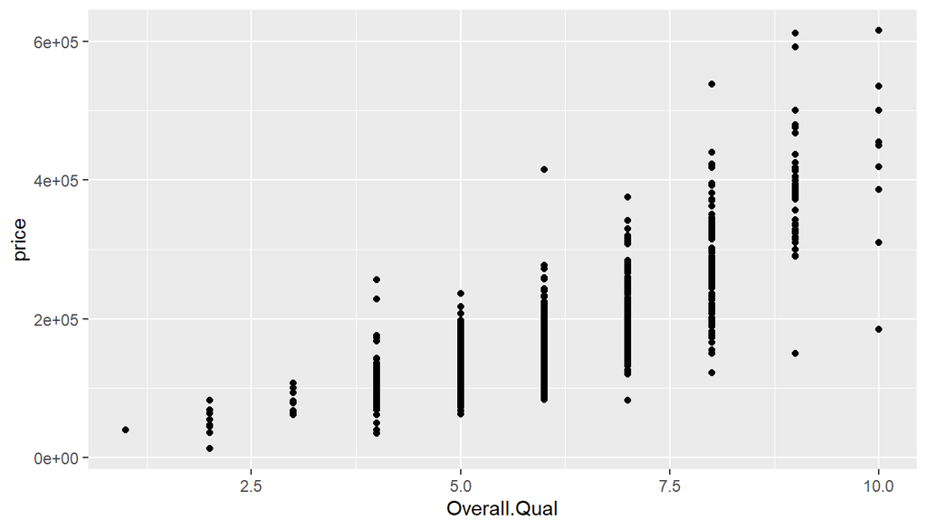

```r
ggplot(ames_train, aes(x = Overall.Qual, y = price)) +
  geom_point()
```

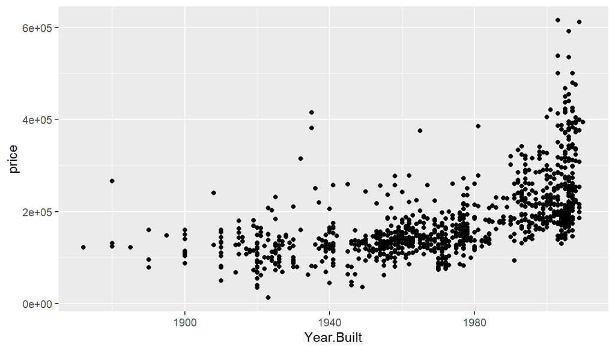

```r
ggplot(ames_train, aes(x = Year.Built, y = price)) +
  geom_point()
```

```r
ames_train %>%
  select(Lot.Area, Bedroom.AbvGr, Overall.Qual, Year.Built, price) %>%
  cor()
```

```
##                  Lot.Area Bedroom.AbvGr Overall.Qual   Year.Built     price
## Lot.Area      1.000000000    0.15340857   0.09642356  0.007922578 0.2644790
## Bedroom.AbvGr 0.153408568    1.00000000   0.09554957 -0.026276794 0.1401601
## Overall.Qual  0.096423555    0.09554957   1.00000000  0.604877025 0.8017491
## Year.Built    0.007922578   -0.02627679   0.60487703  1.000000000 0.5774753
## price         0.264479019    0.14016006   0.80174913  0.577475307 1.0000000
```

5. Suppose you are examining the relationship between `price` and `area`. Which of the following variable transformations makes the relationship appear to be the most linear?
   1. Do not transform either `price` or `area`
   2. Log-transform `price` but not `area`
   3. Log-transform `area` but not `price`
   4. **Log-transform both `price` and `area`**

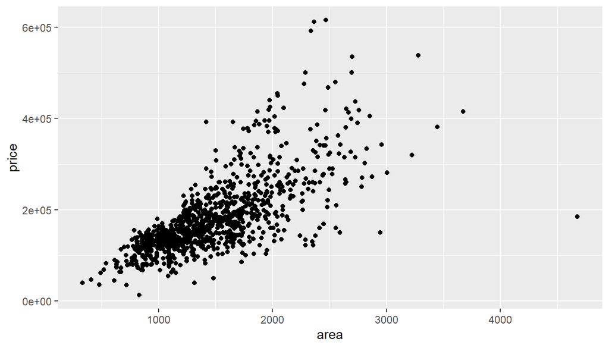

```r
# type your code for Question 5 here, and Knit
ggplot(ames_train, aes(x = area, y = price)) +
  geom_point()
```

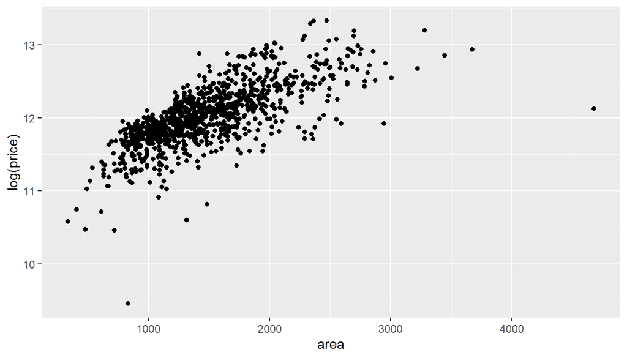

```r
ggplot(ames_train, aes(x = area, y = log(price))) +
  geom_point()
```

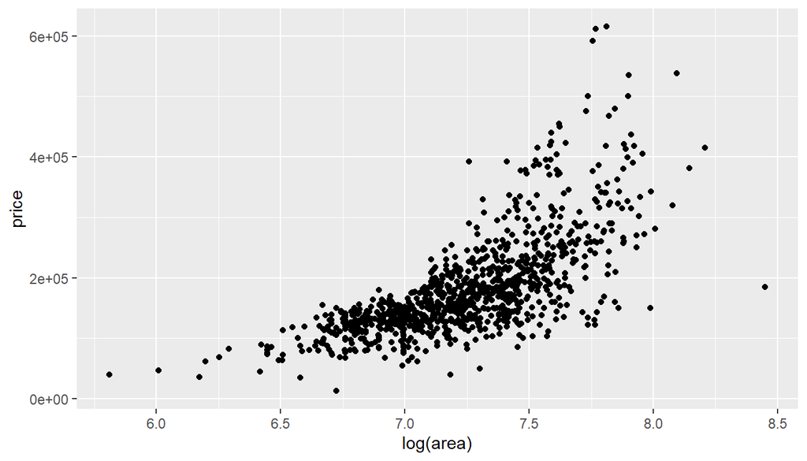

```r
ggplot(ames_train, aes(x = log(area), y = price)) +
  geom_point()
```

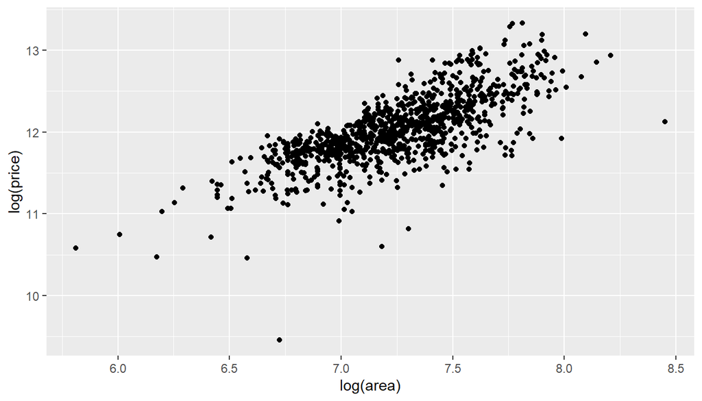

```r
ggplot(ames_train, aes(x = log(area), y = log(price))) +
  geom_point()
```

```r
# type your code for Question 6 here, and Knit
ames_train = ames_train %>%
  mutate('hasGarage' = factor(ifelse(Garage.Area > 0, 1, 0), c(0, 1)))
#nrow(filter(ames_train, Garage.Area == 0))
```

```r
summary(ames_train$hasGarage)
```

```
##    0    1 NA's
##   46  953    1
```

7. Which of the following statements is true about the dataset?
   1. Over 30 percent of houses were built after the year 1999.
   2. The median housing price is greater than the mean housing price.
   3. **21 houses do not have a basement.**
   4. 4 houses are located on gravel streets.

```r
# type your code for Question 7 here, and Knit
#count(ames_train, Year.Built)
ames_train %>%
  group_by(Year.Built) %>%
  summarise(n() / nrow(.))
```

```
## # A tibble: 102 x 2
##    Year.Built `n()/nrow(.)`
##         <int>         <dbl>
##  1       1872         0.001
##  2       1880         0.003
##  3       1885         0.001
##  4       1890         0.003
##  5       1895         0.001
##  6       1900         0.011
##  7       1908         0.002
##  8       1910         0.011
##  9       1914         0.002
## 10       1915         0.006
## # ... with 92 more rows
```

```r
summary(ames_train$price)
```

```
##    Min. 1st Qu.  Median    Mean 3rd Qu.    Max.
##   12789  129763  159467  181190  213000  615000
```

```r
#setNames(aggregate(ames_train$price, list(ames_train$Bsmt.Qual), sd), c('Bsmt.Qual', 'CountPID'))
# NA - No basement
count(ames_train, Bsmt.Qual)
```

```
## # A tibble: 7 x 2
##   Bsmt.Qual     n
##   <fct>     <int>
## 1 ""            1
## 2 "Ex"         87
## 3 "Fa"         28
## 4 "Gd"        424
## 5 "Po"          1
## 6 "TA"        438
## 7  <NA>        21
```

```r
count(ames_train, Street)
```

```
## # A tibble: 2 x 2
##   Street     n
##   <fct>  <int>
## 1 Grvl       3
## 2 Pave     997
```

8. Test, at the $\alpha = 0.05$ level, whether homes with a garage have larger square footage than those without a garage.
   1. **With a p-value near 0.000, we reject the null hypothesis of no difference.**
   2. With a p-value of approximately 0.032, we reject the null hypothesis of no difference.
   3. With a p-value of approximately 0.135, we fail to reject the null hypothesis of no difference.
   4. With a p-value of approximately 0.343, we fail to reject the null hypothesis of no difference.

```r
# type your code for Question 8 here, and Knit
inference(y = area, x = hasGarage, data = ames_train, statistic = 'mean', type = 'ht', null = 0, alternative = 'twosided', method = "theoretical")
```

```
## Response variable: numerical
## Explanatory variable: categorical (2 levels)
## n_0 = 46, y_bar_0 = 1145.0435, s_0 = 445.1805
## n_1 = 953, y_bar_1 = 1492.2508, s_1 = 502.738
## H0: mu_0 =  mu_1
## HA: mu_0 != mu_1
## t = -5.134, df = 45
## p_value = < 0.0001
```

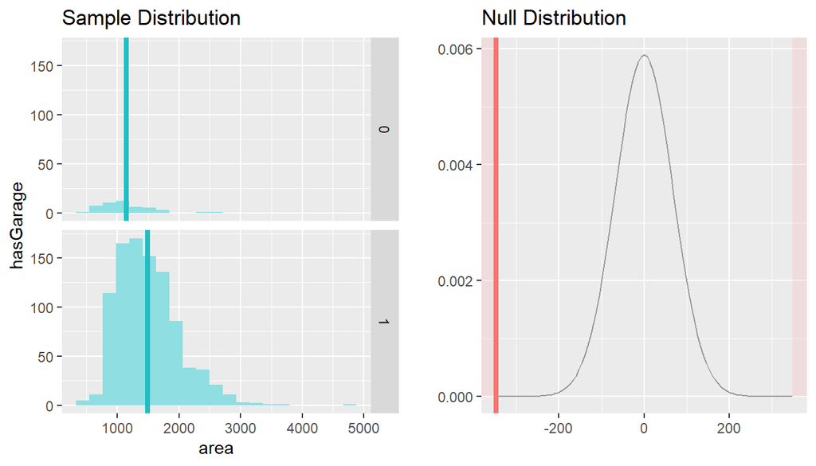

9. For homes with square footage greater than 2000, assume that the number of bedrooms above ground follows a Poisson distribution with rate $\lambda$. Your prior on $\lambda$ follows a Gamma distribution with mean 3 and standard deviation 1. What is your posterior mean and standard deviation for the average number of bedrooms in houses with square footage greater than 2000 square feet?
   1. Mean: 3.61, SD: 0.11
   2. **Mean: 3.62, SD: 0.16**
   3. Mean: 3.63, SD: 0.09
   4. Mean: 3.63, SD: 0.91

```r
# type your code for Question 9 here, and Knit

ames_bed = ames_train %>%
  filter(area > 2000) %>%
    select(Bedroom.AbvGr)

sum(ames_bed$Bedroom.AbvGr)
```

```
## [1] 501
```

```r
k = 9
k_pos = k + sum(ames_bed$Bedroom.AbvGr)
k_pos
```

```
## [1] 510
```

```r
n = nrow(ames_bed)
```

```r
theta = 1/3
theta_pos = theta/(n*theta + 1)
theta_pos
```

```
## [1] 0.007092199
```

```r
mean_post = k_pos * theta_pos
mean_post
```

```
## [1] 3.617021
```

```r
theta_pos*sqrt(k_pos)
```

```
## [1] 0.1601644
```

10. When regressing $\log$(`price`) on $\log$(`area`), there are some outliers. Which of the following do the three most outlying points have in common?
    1. They had abnormal sale conditions.
    2. They have only two bedrooms.
    3. They have an overall quality of less than 3.
    4. **They were built before 1930.**

```r
# type your code for Question 10 here, and Knit

ames_train = ames_train %>%
  mutate(l_price = log(price),
         l_area = log(area))

lm.simple = lm(l_price ~ l_area, data = ames_train)
summary(lm.simple)
```

```
##
## Call:
## lm(formula = l_price ~ l_area, data = ames_train)
##
## Residuals:
##      Min       1Q   Median       3Q      Max
## -2.08526 -0.14145  0.02048  0.17002  0.84536
##
## Coefficients:
##             Estimate Std. Error t value Pr(>|t|)
## (Intercept)  5.34441    0.19262   27.75   <2e-16 ***
## l_area       0.92167    0.02657   34.69   <2e-16 ***
## ---
## Signif. codes:  0 '***' 0.001 '**' 0.01 '*' 0.05 '.' 0.1 ' ' 1
##
## Residual standard error: 0.2834 on 998 degrees of freedom
## Multiple R-squared:  0.5466, Adjusted R-squared:  0.5461
## F-statistic:  1203 on 1 and 998 DF,  p-value: < 2.2e-16
```

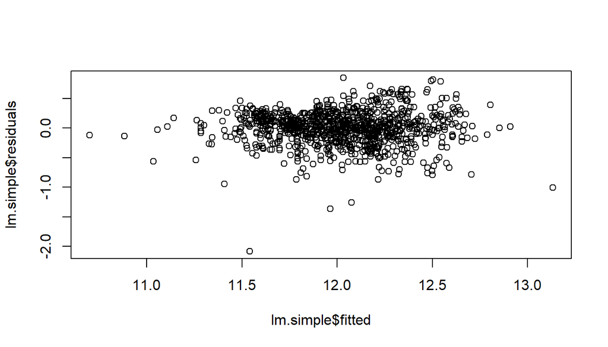

```r
plot(lm.simple$residuals ~ lm.simple$fitted)
```

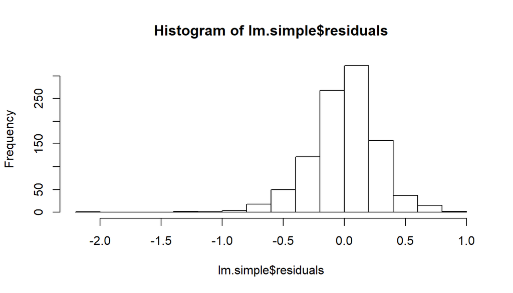

```r
hist(lm.simple$residuals)
```

```r
lm.simple$residuals[lm.simple$residuals < -1]
```

```
##       206       310       428       741
## -1.255158 -1.005985 -2.085256 -1.368268
```

```r
ames_train[c(206, 310, 428, 741),] %>%
  select(Sale.Condition, Bedroom.AbvGr, Overall.Qual, Year.Built)
```

```
## # A tibble: 4 x 4
##   Sale.Condition Bedroom.AbvGr Overall.Qual Year.Built
##   <fct>                  <int>        <int>      <int>
## 1 Abnorml                    3            4       1910
## 2 Partial                    3           10       2007
## 3 Abnorml                    2            2       1923
## 4 Normal                     3            4       1920
```

11. Which of the following are reasons to log-transform `price` if used as a dependent variable in a linear regression?
    1. **`price` is right-skewed.**
    2. `price` cannot take on negative values.
    3. `price` can only take on integer values.
    4. Both a and b.

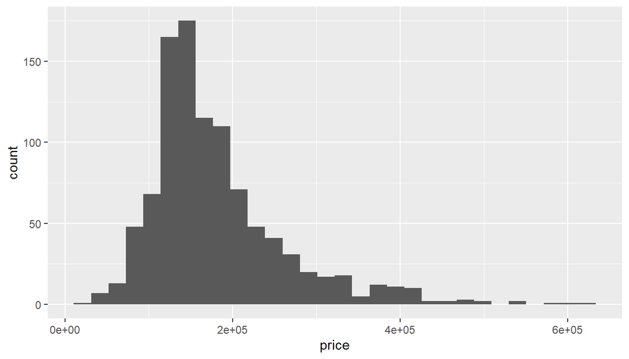

```r
# type your code for Question 11 here, and Knit
ggplot(ames_train, aes(x = price)) +
  geom_histogram()
```

12. How many neighborhoods consist of only single-family homes? (e.g. `Bldg.Type` = `1Fam`)
    1. 0
    2. 1
    3. 2
    4. 3

```r
# type your code for Question 12 here, and Knit
ames_train %>%
  filter(Bldg.Type == '1Fam') %>%
  select(Neighborhood) %>%
  group_by(Neighborhood) %>%
  count()
```

```
## # A tibble: 21 x 2
## # Groups:   Neighborhood [21]
##    Neighborhood     n
##    <fct>        <int>
##  1 Blmngtn          2
##  2 BrkSide         40
##  3 ClearCr         13
##  4 CollgCr         82
##  5 Crawfor         25
##  6 Edwards         48
##  7 Gilbert         48
##  8 IDOTRR          33
##  9 Mitchel         35
## 10 NAmes          143
## # ... with 11 more rows
```

```r
ames_train %>%
  group_by(Neighborhood) %>%
  summarise(mean(Bldg.Type == "1Fam"))
```

```
## # A tibble: 27 x 2
##    Neighborhood `mean(Bldg.Type == "1Fam")`
##    <fct>                              <dbl>
##  1 Blmngtn                            0.182
##  2 Blueste                            0
##  3 BrDale                             0
##  4 BrkSide                            0.976
##  5 ClearCr                            1
##  6 CollgCr                            0.965
##  7 Crawfor                            0.862
##  8 Edwards                            0.8
##  9 Gilbert                            0.980
## 10 Greens                             0
## # ... with 17 more rows
```

13. Using color, different plotting symbols, conditioning plots, etc., does there appear to be an association between $\log$(`area`) and the number of bedrooms above ground (`Bedroom.AbvGr`)?
    1. **Yes**
    2. No

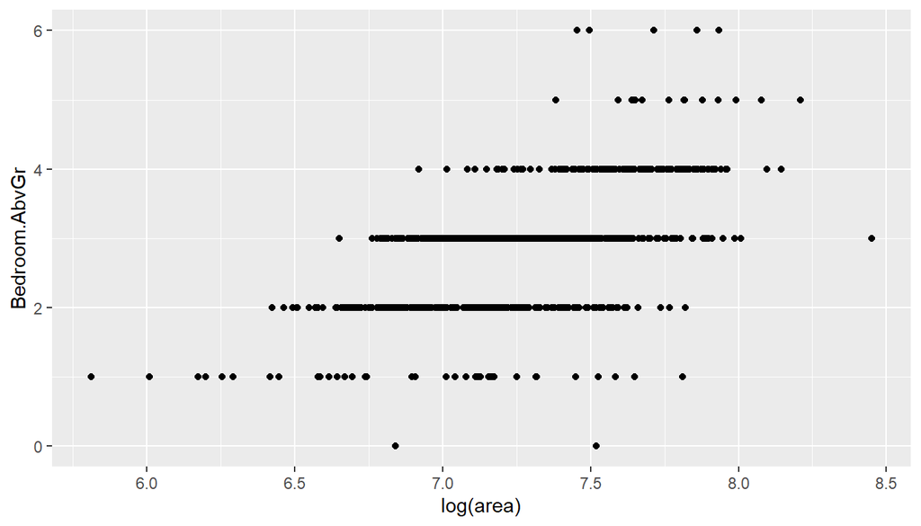

```r
# type your code for Question 13 here, and Knit
ggplot(ames_train, aes(x = log(area), y = Bedroom.AbvGr)) +
  geom_point()
```

14. Of the people who have unfinished basements, what is the average square footage of the unfinished basement?
    1. 590.36
    2. **595.25**
    3. 614.37
    4. 681.94

```r
# type your code for Question 14 here, and Knit
ames_train %>%
  filter(Bsmt.Unf.SF > 0) %>%
  select(Bsmt.Unf.SF) %>%
  summary()
```

```
##   Bsmt.Unf.SF
##  Min.   :  17.0
##  1st Qu.: 271.5
##  Median : 515.5
##  Mean   : 595.3
##  3rd Qu.: 809.5
##  Max.   :2336.0
```